# Applied Biogeography - koodi- ja mallinnusnäyte

Pyry Toivonen

2024-04-19

Palaa portfolion aloitussivulle

Koodin konteksti: Koodi on osa Turun yliopiston Applied Biogeography -kurssin ryhmätyöprojektia, jossa mallinnetaan Havuparikkaan (sieni, Diploidia sapinea) ja okakaarnakuoriaisen (Ips acuminatus) leviämistä ja levinneisyyttä saaristossa.

Koodissa suoritetaan spatiaalista analyysiä sekä tilastollista mallinnusta spatiaalisesta aineistosta, soveltaen dispersaaliekologian teoriaa ja tilastollisia menetelmiä.

Koodin on kirjoittanut kokonaan Pyry Toivonen

Alkuvalmisteluja varten käytetään seuraavia paketteja.

```r
library(sf)
library(ggplot2)
library(cowplot)
library(tidyverse)
```

Luodaan aineisto saariryhmille - yhdistetään lähellä toisiaan (max 100 metrin säteellä) olevat saaret saariryhmiksi

```r
AOI <- st_read("AOI.shp") # Tuodaan Area of Interest
Meri <- st_read("meri10.shp") # Tuodaan meriaineisto
```

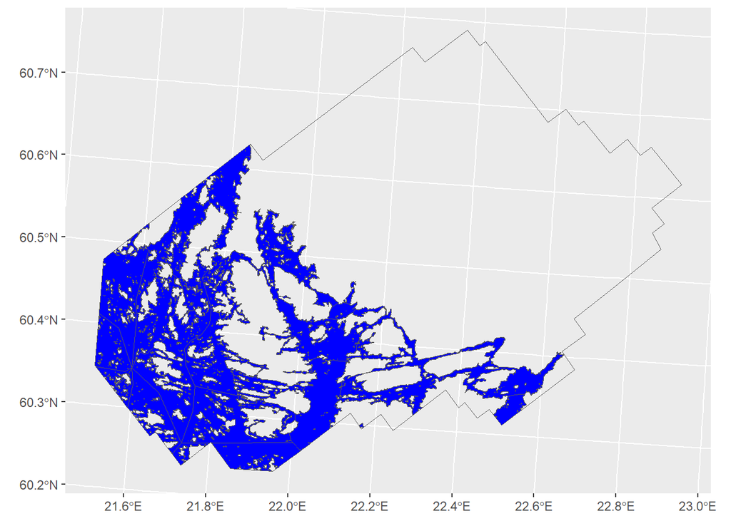

```r
Meri <- st_intersection(Meri, AOI) # Leikataan merialue AOI:lla



# Plotataan ja tarkistetaan
MeriPlot <- ggplot() +
  geom_sf(data=AOI, fill=NA) +
  geom_sf(data=Meri, fill="blue")
MeriPlot
```

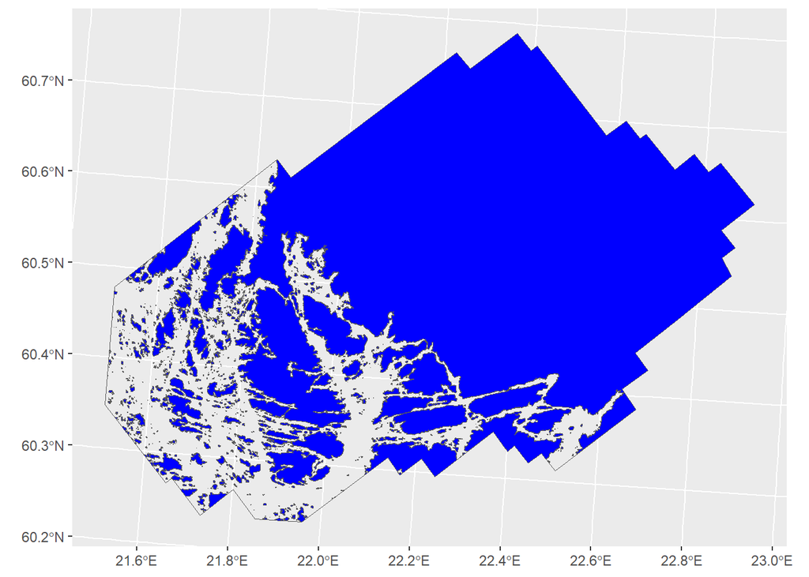

```r
Meri <- st_union(Meri) # Yhdistetään meriaineiston polygonit yhdeksi isoksi polygoniksi
Saaret <- st_difference(AOI, Meri) # Invertoidaan meripolygoni, jotta saadaan saaripolygoni

# Plotataan ja tarkistetaan
SaariPlot <- ggplot() +
  geom_sf(data=AOI, fill=NA) +
  geom_sf(data=Saaret, fill="blue")
SaariPlot
```

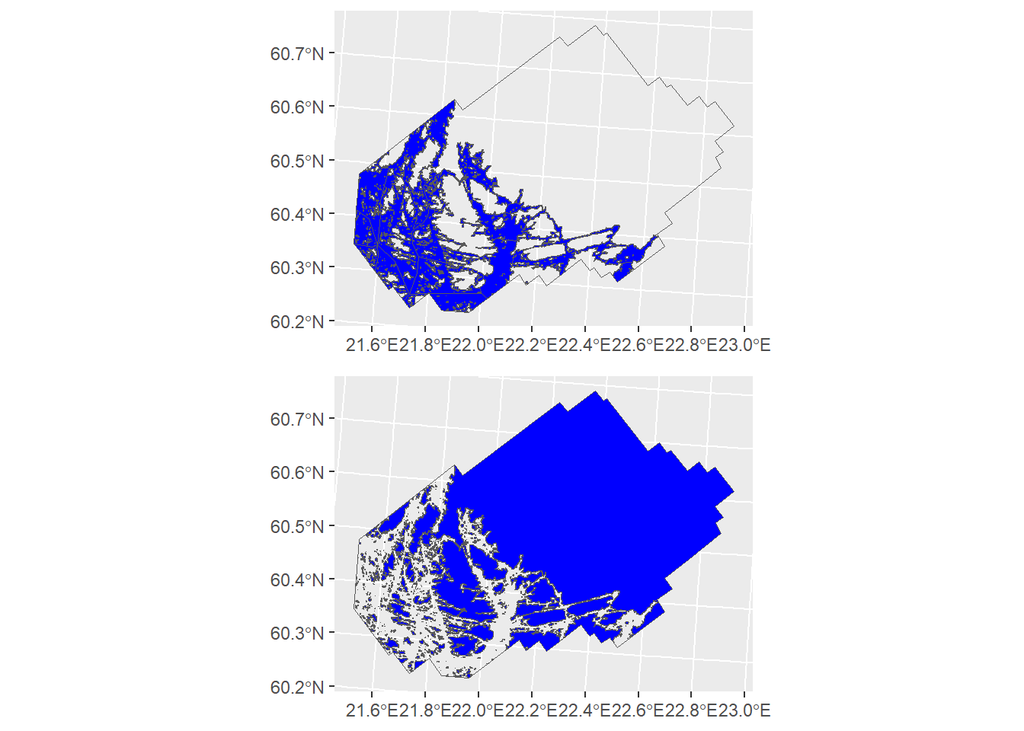

```r
# Allekkain
plot_grid(MeriPlot, SaariPlot, ncol=1) #ncol = 1 -> kolumnien määrä 1 eli kuvat menee allekkain
```

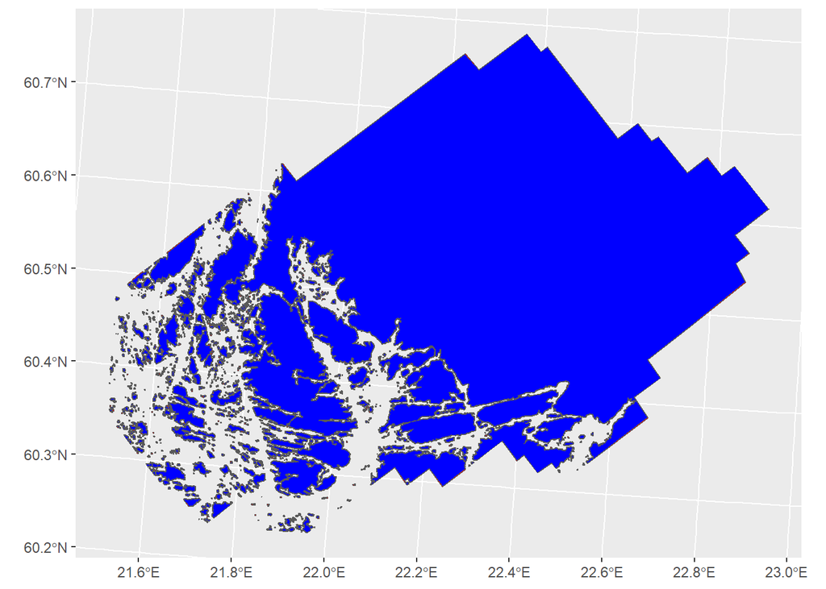

```r
# Seuraavaksi luodaan bufferit, joilla yhdistetään max 100 metrin päässä toisitaan olevat saaret saariryhmiksi
Buffer50 <- st_buffer(Saaret, 50) # 50x2 = korkeintaan 100 m etäisyys saarten välillä

ggplot() +
  geom_sf(data=Buffer50, fill="red") +
  geom_sf(data=Saaret, fill="blue")
```

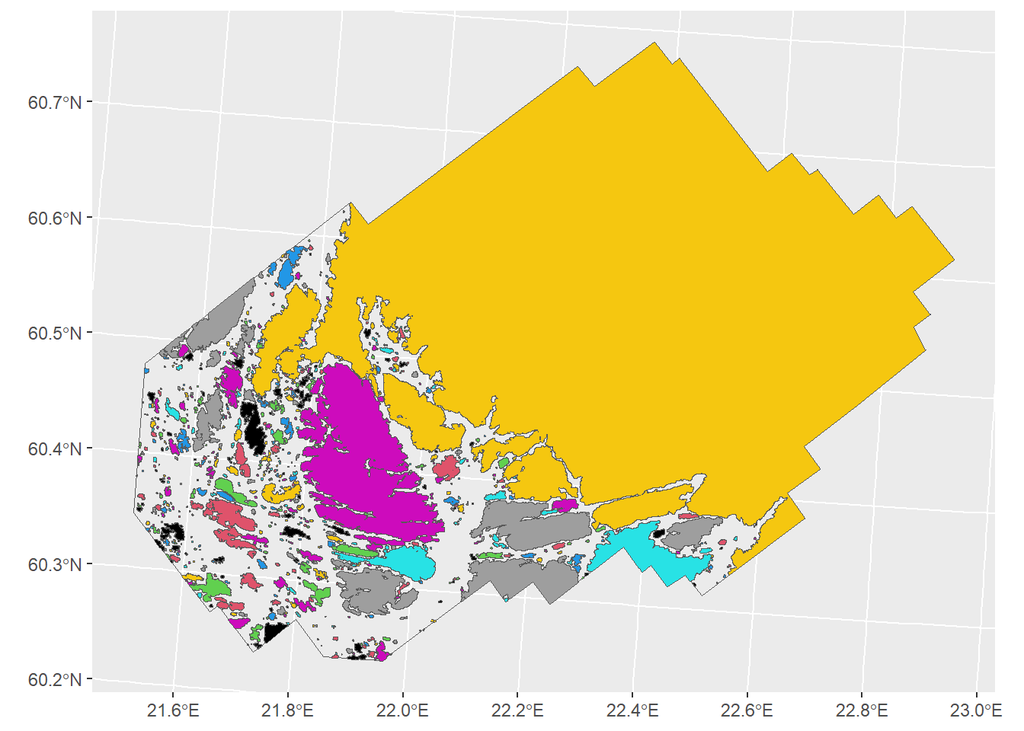

```r
#st_write(Buffer50, "SaariBuffer50m.shp")

Bufferit <- st_cast(Buffer50, "POLYGON") # Muutetaan MULTIPOLYGON objekti POLYGON objektiksi. Eli jokainen bufferi on oma polygoninsa.

Saariryhmat <- st_union(Bufferit) # Yhdistetään toisiaan koskettavat polygonit

Saariryhmat <- st_cast(Saariryhmat, "POLYGON") # Muutetaan MULTIPOLYGON objekti POLYGON objektiksi
Saariryhmat <- st_sf(Saariryhmat) # Muutetaan sfc-objekti sf-objektiksi eli taulukkomuotoon
Saariryhmat$ID <- 1:nrow(Saariryhmat)

#st_write(Saariryhmat, "Saariryhmat.shp", append=T)

# Tarkastetaan, miltä saariryhmat näyttävät
ggplot() +
  geom_sf(data=AOI, fill=NA) +
  geom_sf(data=Saariryhmat, fill=Saariryhmat$ID)
```

Seuraavaksi käsitellään laikkuaineistoa ja tehdään siitä pistemuotoista analyyseja varten

```r
Laikut <- st_read("Mortality_polygons_distinct.gpkg") # Tuodaan laikut
```

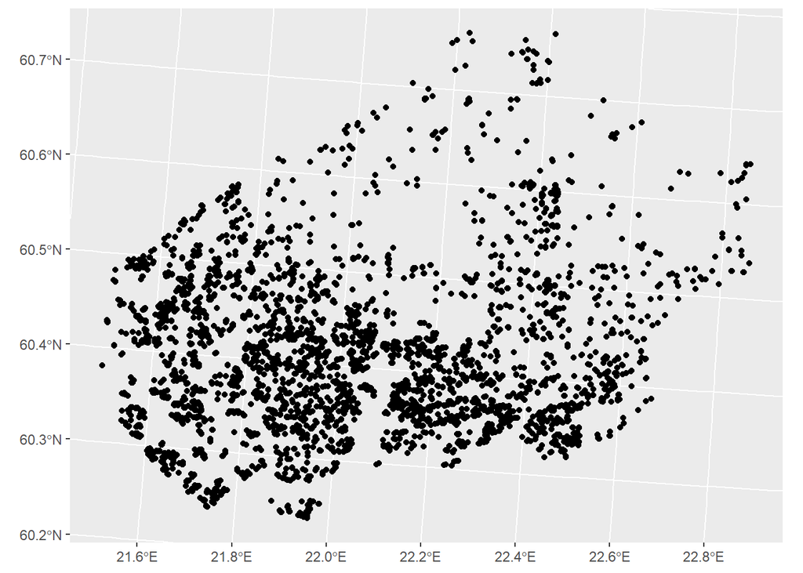

```r
Laikut <- Laikut[!st_is_empty(Laikut),] # Poistetaan tyhjät geometriat

## Muutetaan laikuista pisteet. Tämän olen jo mahdollistanut helposti luomalla centroid.X ja centroid.Y kolumnit

# Ensin tallennetaan kuitenkin tieto polygonien eli laikkujen pinta-alasta
Laikut$Area_m2 <- as.vector(st_area(Laikut))

# Sitten tehdään pisteaineisto
Laikkupisteet <- st_as_sf(st_drop_geometry(Laikut), coords=c("centroid.X","centroid.Y"), remove=F)

st_crs(Laikkupisteet) <- 3067 # asetetaan crs

ggplot() +
  geom_sf(data=Laikkupisteet)
```

```r
# Sitten yhdistetään pisteet saariryhmiin

Saariryhmat <- Saariryhmat %>%
  rename(SaarID = ID) # Nimetään ID uudelleen, jotta sen erottaa varmasti

# Liitetään pisteisiin se saariryhmän tunnus (SaarID), jonka sisällä piste on.
Laikut_joined <- st_join(Laikkupisteet, Saariryhmat, join=st_intersects)
Laikut_joined$SaarID <- as.factor(Laikut_joined$SaarID)

## Jaetaan laikut harmaisiin ja ruskeisiin laikkuihin
# Koska laikut on määritetty samasta vuoden 2023 ilmakuvasta, harmaat laikut ovat vanhoja sukupolvia ja ruskeat uusia
unique(Laikut_joined$Brow.Gray) # Tarkastetaan millä eri tavoin väri on kirjattu
```

```
## [1] "b"     "g"     "B"     NA      "brown" "G"     "grey"  "1"
```

```r
# Yhdistetään nämä eri ilmaistu yhtenäiseksi kolumniksi
Laikut_gray <- Laikut_joined %>%
  filter(Brow.Gray %in% c("G","grey","g")) %>%
  mutate(Generation = "Gray")

Laikut_brown <- Laikut_joined %>%
  filter(Brow.Gray %in% c("B","brown","b")) %>%
  mutate(Generation = "Brown")


### Seuraavaksi määritetään etäisyysmatriiseja ja etäisyyslukuja niistä ###

# Etäisyysmatriisit
DistMatrix_Laikut_All <- st_distance(Laikut_joined) # Etäisyysmatriisi kaikille laikuille
DistMatrix_Laikut_Gen <- st_distance(Laikut_brown, Laikut_gray) # Sukupolvien välinen etäisyys (Brown ja Gray)

## DistMatrix_Laikut_All ##
# Matriisi sisältää kaikki pisteiden väliset etäisyydet
DistMatrix_Laikut_All[1:5,1:5] # sample.
```

```
## Units: [m]
##           1        2         3        4        5
## 1     0.000 17101.30  4886.059 43379.04 64805.37
## 2 17101.299     0.00 14253.347 56245.03 75691.18
## 3  4886.059 14253.35     0.000 43180.79 63845.74
## 4 43379.044 56245.03 43180.790     0.00 22636.67
## 5 64805.373 75691.18 63845.743 22636.67     0.00
```

```r
ncol(DistMatrix_Laikut_All)
```

```
## [1] 4015
```

```r
nrow(DistMatrix_Laikut_All)
```

```
## [1] 4015
```

```r
# Rivit ja kolumnit toistavat itseään, joten voidaan käsitellä vain kolumneja tai rivejä
# Koska apply soveltuu huonosti etäisyysmatriiseihin (laskee mukaan nollan), niin tehdään simppeli for loop.
MinDist <- 1:ncol(DistMatrix_Laikut_All) # luodaan pohjaksi vektorit
MeanDist <- 1:ncol(DistMatrix_Laikut_All)
MeanNetDisp <- 1:ncol(DistMatrix_Laikut_All) # Lasketaan myös mean net squared displacement, joka on tärkeä tunnusluku etäisyyksien tutkimisessa

# Varsinainen for loop
for (i in 1:ncol(DistMatrix_Laikut_All)) {
  MinDist[i] <- sort(DistMatrix_Laikut_All[,i])[2] # ignooraa nollan ottamalla toisiksi pienimmän arvon
  MeanDist[i] <- mean(sort(DistMatrix_Laikut_All[,i][-1]), na.rm=T) # laskee keskiarvon ignooraamalla nollan
  MeanNetDisp[i] <- mean(sqrt(as.vector(sort(DistMatrix_Laikut_All[,i][-1])))) # laskee Mean net squared displacement ignooramalla nollan
}

# Liitetään tulokset taulukkoon
Laikut_joined$MeanDist_m <- MeanDist
Laikut_joined$MinDist_m <- MinDist
Laikut_joined$MeanNetDisp_m2 <- MeanNetDisp


## DistMatrix_Laikut_Gen ##
# Matriisi on nyt erilainen, koska luvut eivät toistukaan eli jokainen solu on uniikki
DistMatrix_Laikut_Gen[1:5,1:5] # sample.
```

```
## Units: [m]
##           [,1]     [,2]      [,3]         [,4]         [,5]
## [1,]  4886.059 53900.10 45391.942 43372.688369 64813.523175
## [2,] 14253.347 65987.36 57977.397 56238.146639 75698.234212
## [3,] 43180.790 10813.57  2254.053     7.050477 22645.863071
## [4,] 63845.743 12035.31 20389.474 22641.310156     9.596098
## [5,] 37243.039 16341.86  8864.689  7879.793484 26708.030809
```

```r
ncol(DistMatrix_Laikut_Gen) # 1660 kolumnia = Kolumneissa on Laikut_gray
```

```
## [1] 1660
```

```r
nrow(DistMatrix_Laikut_Gen) # 2241 riviä = riveissä on Laikut_brown
```

```
## [1] 2241
```

```r
# Nimetään kolumnit ja rivit uudelleen vastaamaan laikkujen ID-arvoja
colnames(DistMatrix_Laikut_Gen) <- Laikut_gray$ID
rownames(DistMatrix_Laikut_Gen) <- Laikut_brown$ID
DistMatrix_Laikut_Gen[1:5,1:5] # tarkastetaan sample uudelleen
```

```
## Units: [m]
##           3      253       254          255          256
## 1  4886.059 53900.10 45391.942 43372.688369 64813.523175
## 2 14253.347 65987.36 57977.397 56238.146639 75698.234212
## 4 43180.790 10813.57  2254.053     7.050477 22645.863071
## 5 63845.743 12035.31 20389.474 22641.310156     9.596098
## 6 37243.039 16341.86  8864.689  7879.793484 26708.030809
```

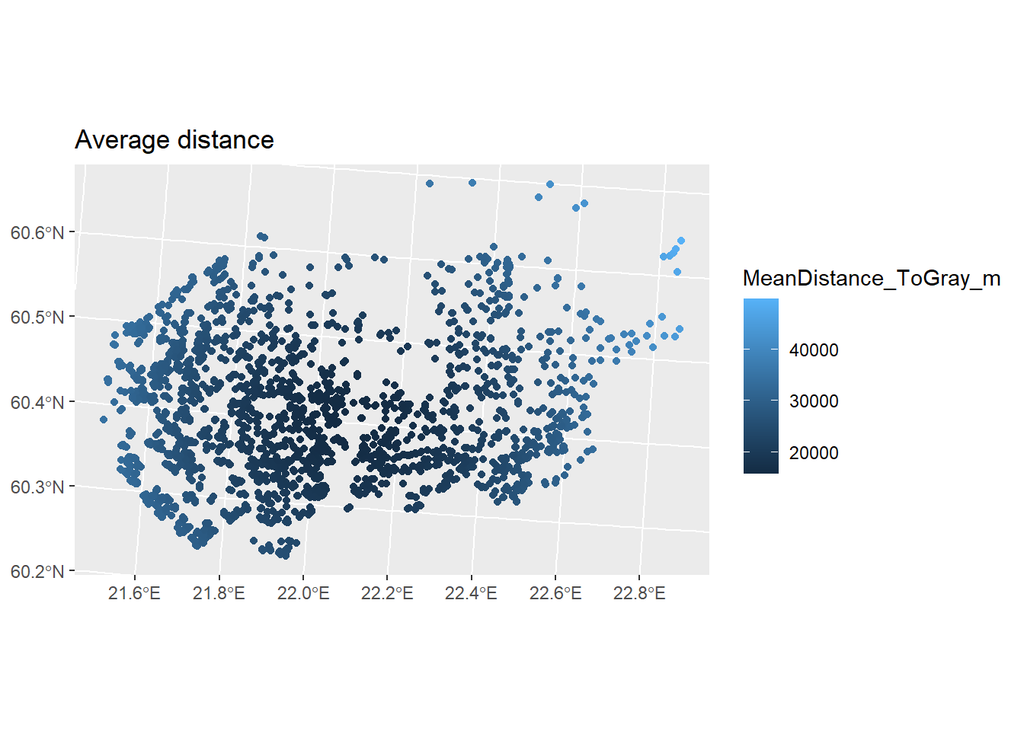

```r
# For loopin sijaan tehdään nämä apply-funktiolla vaihtelun vuoksi
# Kun lasketaan rivien keskiarvot tiedetään kuinka kaukana kyseinen rivi (ruskea laikku) on keskimäärin harmaista laikuista (kolumnit)
# Sama logiikka pätee minimin kohdalla, mutta lasketaan pienin etäisyys harmaaseen laikkuun jokaiselle riville (ruskealle laikulle)
# Lasketaan vain ruskeille laikuille etäisyydet, koska ne ovat uudempi sukupolvi

Laikut_brown$MeanDistance_ToGray_m <- apply(DistMatrix_Laikut_Gen, 1, FUN = mean)
Laikut_brown$MinDistance_ToGray_m <- apply(DistMatrix_Laikut_Gen, 1, FUN = min)
Laikut_brown$MeanNetDisp_m2 <- apply(DistMatrix_Laikut_Gen, 1, function(x) mean(sqrt(x))) # suoritetaan useampi funktio oikeassa järjestyksessä


ggplot() +
  geom_sf(data=Laikut_brown, aes(col=MeanDistance_ToGray_m)) +
  ggtitle("Average distance")
```

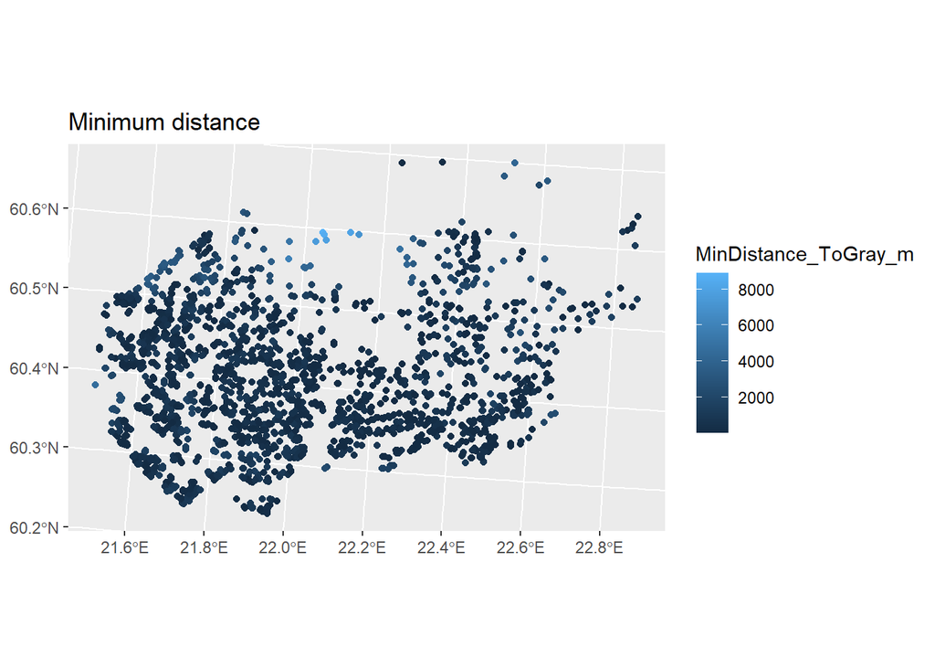

```r
ggplot() +
  geom_sf(data=Laikut_brown, aes(col=MinDistance_ToGray_m)) +
  ggtitle("Minimum distance")
```

```r
# Nähdään, että vaikka keskimääräisissä etäisyyksissä on vaihtelua, niin vähemmän vaihtelua on minimietäisyyksissä
# Eli myös kaukana tiheimmästä alueesta sijaitsevat pisteet ovat lähellä toisia pisteitä
# Näin usein lajit levittäytyvät sekä harvinaisten pitkien matkojen että yleisempien lyhyiden matkojen yhteistyössä
```

Seuraavaksi lasketaan, missä pisteiden tiheydet ovat suurimmat eli toisin sanoen millä alueella etäisyydet ovat keskimäärin pienimmät. Tästä pisteestä oletetaan dispersaaliteorian mukaan ilmiön levinneen muuallekin.

Tehdään tämä kahdella tapaa: huomioiden sukupolven (käyttämällä vain ruskeita pisteitä ja niiden etäisyyttä harmaisiin pisteisiin) sekä huomioimatta sitä eli käyttämällä kaikkia pisteitä ja niiden välistä etäisyysverkkoa

```r
sort(Laikut_joined$MeanNetDisp_m2)[1:20]
```

```
##  [1] 127.2533 127.2612 127.2615 127.2646 127.2672 127.2712 127.2724 127.2794
##  [9] 127.2818 127.2819 127.2844 127.2863 127.2868 127.2868 127.2974 127.3005
## [17] 127.3048 127.3089 127.3109 127.3240
```

```r
Tiheyskeskus <- Laikut_joined %>%
  filter(MeanNetDisp_m2 < 127.5) # luku saadaan tarkastelemalla kolumnin arvojakaumaa (valitaan sopiva väli pienimpiä lukuja)

sort(Laikut_brown$MeanNetDisp_m2)[1:20]
```

```
##  [1] 119.7593 119.9358 119.9536 120.0184 120.1027 120.1363 120.1472 120.1621
##  [9] 120.1751 120.1941 120.2252 120.2460 120.2809 120.2917 120.4404 120.4771
## [17] 120.4782 120.6241 120.6332 120.6586
```

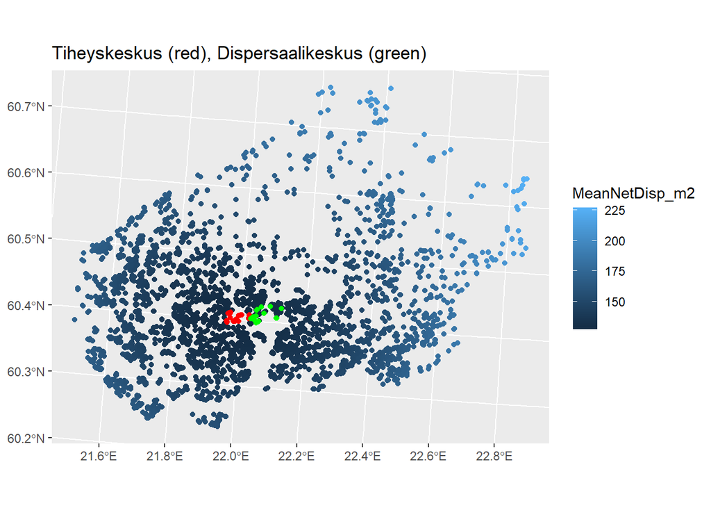

```r
# Kutsutaan tätä dispersaalikeskukseksi, koska sukupolvi sisältää ajallisen aspektin: harmaat ovat tulleet aikaisemmin kuin ruskeat. Eli ruskeiden laikkujen etäisyys on laskettu ajallisesti vanhempiin laikkuihin
Dispersaalikeskus <- Laikut_brown %>%
  filter(MeanNetDisp_m2 < 120.5)

ggplot() +
  geom_sf(data=Laikut_joined, aes(col=MeanNetDisp_m2)) +
  geom_sf(data=Tiheyskeskus, col="red") +
  geom_sf(data=Dispersaalikeskus, col="green") +
  ggtitle("Tiheyskeskus (red), Dispersaalikeskus (green)")
```

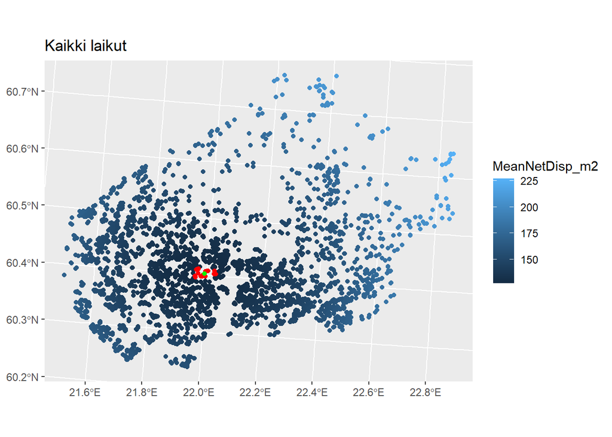

```r
# Mäyttää siltä, että tiheyskeskus ja dispersaalikeskus matchaavat jollain tarkkuudella toisiinsa
# Tämä mielestäni vahvistaa sitä ajatusta, että tiheyskeskus kuvaa hyvin ilmiön levinneisyyden ydinaluetta (myös ajallisesti)

# Lasketaan keskuksille sentroidit

Koordinaatit <- st_coordinates(Tiheyskeskus) # Eristetään keskuksen koordinaatit
Koordinaatit <- rbind(Koordinaatit, Koordinaatit[1,]) # Suljetaan koordinaattien kehä toistamalla eka koordinaatti myös lopussa

# Luodaan koordinaateista taulukko ja tehdään niistä pistemuotoinen sf-objekti
keskus <- data.frame(X=mean(Koordinaatit[,1]), Y=mean(Koordinaatit[,2]))
Tiheyskeskus_centroid <- st_as_sf(keskus, coords=c("X","Y"), crs=st_crs(Tiheyskeskus))

# Toistetaan sama, mutta dispersaalikeskukselle
Koordinaatit <- st_coordinates(Dispersaalikeskus)
Koordinaatit <- rbind(Koordinaatit, Koordinaatit[1,])

keskus <- data.frame(X=mean(Koordinaatit[,1]), Y=mean(Koordinaatit[,2]))
Dispersaalikeskus_centroid <- st_as_sf(keskus, coords=c("X","Y"), crs=st_crs(Dispersaalikeskus))

# Tarkastetaan keskusten sentroidit kartalla
ggplot() +
  geom_sf(data=Laikut_joined, aes(col=MeanNetDisp_m2)) +
  geom_sf(data=Tiheyskeskus, col="red") +
  geom_sf(data=Tiheyskeskus_centroid, col = "green") +
  ggtitle("Kaikki laikut")
```

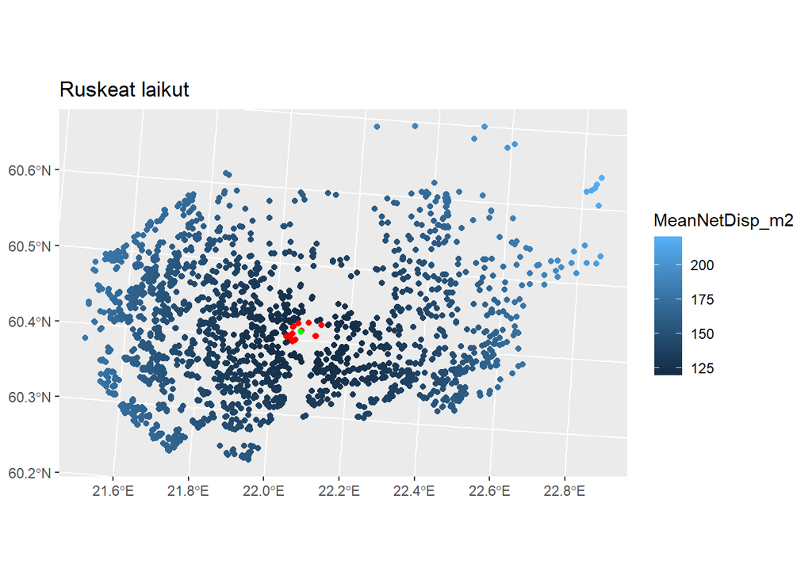

```r
ggplot() +
  geom_sf(data=Laikut_brown, aes(col=MeanNetDisp_m2)) +
  geom_sf(data=Dispersaalikeskus, col="red") +
  geom_sf(data=Dispersaalikeskus_centroid, col = "green") +
  ggtitle("Ruskeat laikut")
```

Seuraavaksi lasketaan tiheys- ja dispersaalikeskusten sentroideista eli keskipisteistä displacement eli kuinka kaukana laikut ovat keskipisteestä

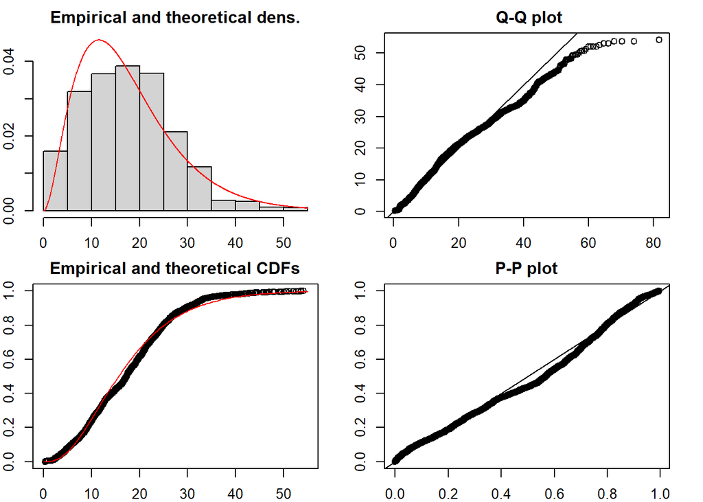

```r
# Lasketaan displacement ja luodaan samalla parempi Generation kolumni
Laikut_joined <- Laikut_joined %>%
  mutate(Displacement = as.vector(st_distance(Laikut_joined, Tiheyskeskus_centroid))) %>%
  mutate(Generation = case_when(Brow.Gray %in% c("g","G","gray") ~ "Gray",
                                Brow.Gray %in% c("b","B","brown") ~ "Brown",
                                .default = NA))

Laikut_brown <- Laikut_brown %>%
  mutate(Displacement = as.vector(st_distance(Laikut_brown, Dispersaalikeskus_centroid)))

## Tarkistetaan minkälaisia jakaumia nämä etäisyysjakaumat ("dispersaalikernelit") noudattaa
library(fitdistrplus)

# Näytetään kaksi parhaiten sopivaa jakaumaa testatuista (poistin koodista ne, jotka eivät sopineet yhtä hyvin)
# Testattu jakaumia norm, lnorm, gamma ja weibull
par(mar=c(2,2,2,2))

# Kaikki laikut - etäisyys tiheyskeskuksesta
fitGamma <- fitdist(Laikut_joined$Displacement/1000, "gamma", method="mle")
plot(fitGamma)
```

```r
summary(fitGamma) # AIC 29133.42
```

```
## Fitting of the distribution ' gamma ' by maximum likelihood
## Parameters :
##        estimate  Std. Error
## shape 2.8937743 0.061221445
## rate  0.1648077 0.003807008
## Loglikelihood:  -14564.71   AIC:  29133.42   BIC:  29146.01
## Correlation matrix:
##           shape      rate
## shape 1.0000000 0.9158115
## rate  0.9158115 1.0000000
```

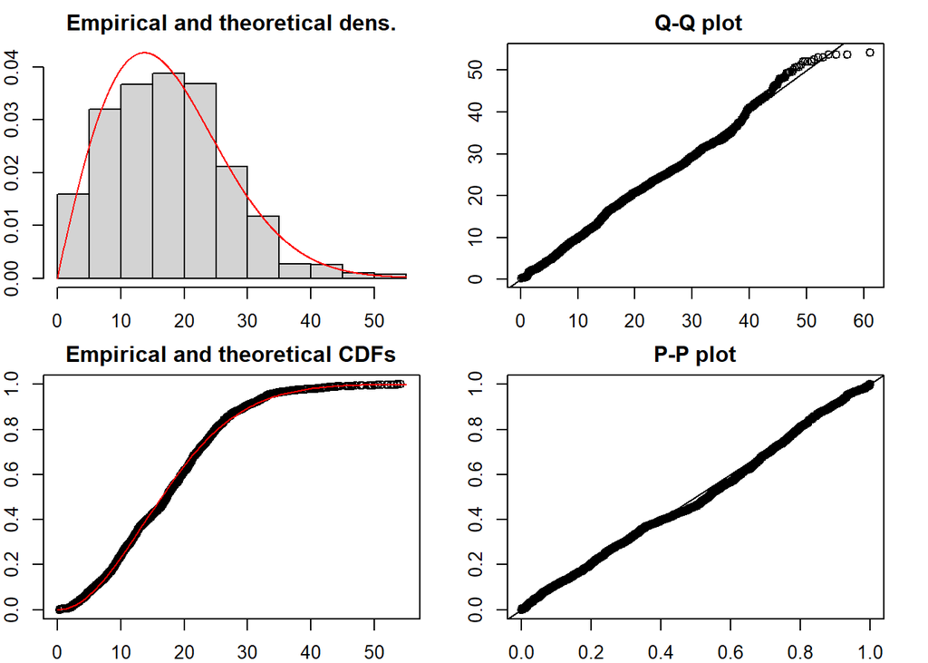

```r
fitWeibull <- fitdist(Laikut_joined$Displacement/1000, "weibull", method="mle")
plot(fitWeibull)
```

```r
summary(fitWeibull) # AIC 28939.33 PARAS
```

```
## Fitting of the distribution ' weibull ' by maximum likelihood
## Parameters :
##        estimate Std. Error
## shape  1.948077 0.02417792
## scale 19.773654 0.16841107
## Loglikelihood:  -14467.67   AIC:  28939.33   BIC:  28951.93
## Correlation matrix:
##           shape     scale
## shape 1.0000000 0.3089817
## scale 0.3089817 1.0000000
```

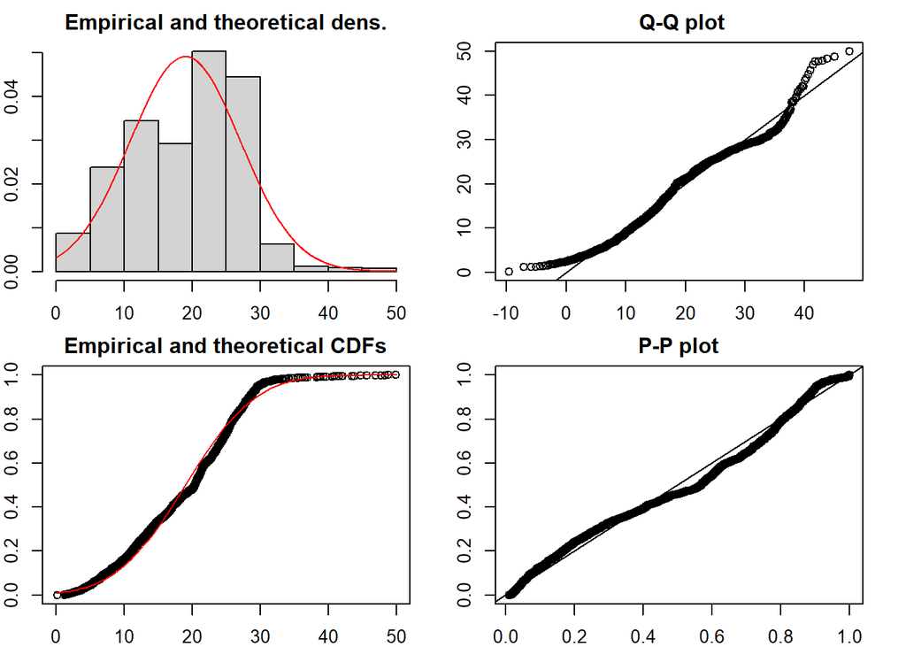

```r
# Ruskeat laikut - etäisyys harmaiden laikkujen keskipisteestä
fitNorm <- fitdist(Laikut_brown$Displacement/1000, "norm", method="mle")
plot(fitNorm)
```

```r
summary(fitNorm) # AIC 15753.91 hitusen parempi, mutta silti heikko osuvuus
```

```
## Fitting of the distribution ' norm ' by maximum likelihood
## Parameters :
##       estimate Std. Error
## mean 18.977736  0.1716598
## sd    8.126238  0.1213818
## Loglikelihood:  -7874.956   AIC:  15753.91   BIC:  15765.34
## Correlation matrix:
##      mean sd
## mean    1  0
## sd      0  1
```

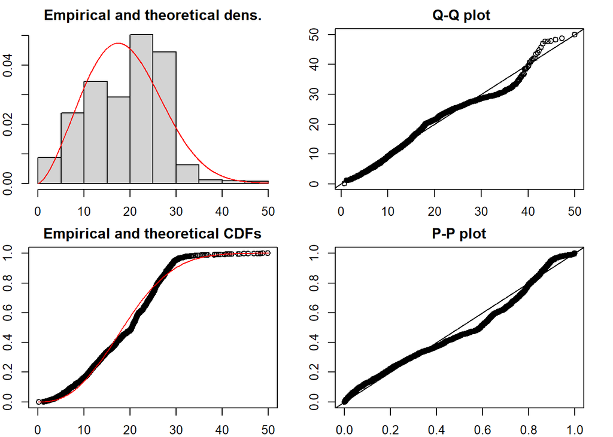

```r
fitWeibull <- fitdist(Laikut_brown$Displacement/1000, "weibull", method="mle")
plot(fitWeibull)
```

```r
summary(fitWeibull) # AIC 15755.01
```

```
## Fitting of the distribution ' weibull ' by maximum likelihood
## Parameters :
##        estimate Std. Error
## shape  2.502788  0.0429539
## scale 21.334897  0.1885291
## Loglikelihood:  -7875.506   AIC:  15755.01   BIC:  15766.44
## Correlation matrix:
##           shape     scale
## shape 1.0000000 0.2959319
## scale 0.2959319 1.0000000
```

```r
## TULOS: Mallinnukset kannattaa tehdä kokolaikkuaineistolla, jonka johtopäätöksiä laikut_brown data tukee.
# Tämä koska:
# 1. Laikut_brown raaka-aineistolle ei löydy heti helposti sopivaa jakaumaa
# 2. Dispersaalikeskus ja tiheyskeskus ovat riittävän lähellä toisiaan
# Mallinnus vaatii mallin, joka tukee Weibull-jakaumaa (GAMLSS package)
# https://www.gamlss.com/
# Data on right-truncated siinä mielessä, että se rajoittuu meidän tutkimusalueeseen ja sen ulkopuolelle mahdollisesti jäävät arvot jäävät rekisteröimättä
# Tämän right-truncated ominaisuuden voisi huomioida jakaumassa, mutta se on hiukan monimutkaista

# Tallennetaan laikut GeoPackage-muodossa
#st_write(Laikut_joined, "PINE_laikut.gpkg")
#st_write(Laikut_brown, "Laikut_brown.gpkg")
```

Seuraavaksi valmistellaan saaridata mallinnusta varten

```r
# Tuodaan data ja valmistellaan se. Nämä aineistot valmisteltiin yllä, eikä niitä tarvitsisi tuoda uudestaan ellei aloita koodia tästä kohtaan myöhemmin.
Saariryhmat <- st_read("Saariryhmat.shp")
Laikut <- st_read("PINE_laikut.gpkg")
Saariryhmat <- Saariryhmat %>%
  rename(SaarID = ID) # nimetään ID-kolumni uudelleen

## Selvitetään, kuinka monta infektoitunutta/infestoitunutta puuta saarilla on
# Kun kartoitimme laikkuja, laskimme laikkujen sisällä olevien ruskeiden ja/tai harmaiden puiden määrät. Eli laikkudata sisältää tiedon ruskeiden/harmaiden puiden määrästä

# Poistetaan laikkudatasta NA-arvot, koska riveillä, joissa ei ole tietoa puiden määrästä ei tee mitään.
Laikut <- Laikut %>%
     drop_na(No_of_tree)

# Tehdään subset laikkudatasta, josta on poistettu laikut, jotka on vain yhden puun suuruisia. Nämä eivät ole luotettavia, saattavat olla osa läheisiä muita laikkuja tai ovat todella yksilötapauksia. Eli laikkujen rajaksi asetetaan vähintään 2 puuta. Tätä aineistoa käytetään varsinaisissa malleissa, koska se on varmempi.
Laikut_1removed <- Laikut %>%
  filter(No_of_tree > 1)

# Sitten lasketaan saarikohtaisesti infektoituneiden puiden summa. Tehdään tämä huomioiden molemmat ylläolevista tilanteista (yhden puun laikut huomioiden huomioiden ja ne poissulkien)
TreeCount <- aggregate(No_of_tree ~ SaarID, FUN = "sum", data = Laikut)
TreeCount_1removed <- aggregate(No_of_tree ~ SaarID, FUN = "sum", data = Laikut_1removed)

TreeCount <- TreeCount %>%
  rename(Trees = No_of_tree) # nimetään paremmin

TreeCount_1removed <- TreeCount_1removed %>%
  rename(Trees_1removed = No_of_tree) # nimetään paremmin

# Muutetaan SaarID kaikille samaan faktori-muotoon
Saariryhmat$SaarID <- as.factor(Saariryhmat$SaarID)
TreeCount$SaarID <- as.factor(TreeCount$SaarID)
TreeCount_1removed$SaarID <- as.factor(TreeCount_1removed$SaarID)

# Yhdistetään tiedot puiden summista saariaineistoon
Saariryhmat <- Saariryhmat %>%
  left_join(TreeCount) %>%
  left_join(TreeCount_1removed)
# Muutetaan NA-arvot nolliksi, koska ne johtuvat siitä, että saarella ei ollut puita (0 puuta)
Saariryhmat[is.na(Saariryhmat)] <- 0


### Lisätään seuraavaksi lisää muuttujia saariaineistoon

# Lasketaan ja lisätään saarten pinta-ala
Saariryhmat$SaarArea_ha <- as.vector(st_area(Saariryhmat))/10000


## Seuraavien muuttujien luomista varten jaetaan saariryhmat laikullisiin ja ei-laikullisiin

# Luodaan subset saaridatasta, joka sisältää vain ei-infektoituneet saaret
Saaret0 <- Saariryhmat %>%
  filter(Trees_1removed == 0) # Ei-infektoitunut = infektoituneita puita on 0

# Subset saaridatasta, joka sisältää vain infektoituneet saaret
Saaret1 <- Saariryhmat %>%
  filter(Trees_1removed > 1) # pienin arvo jonka infektoituneet saaret saa on 2
```

Seuraavaksi lasketaan saarten välisiä etäisyyksiä, mutta RMarkdown katkaistaan tässä, koska saarten etäisyyksien laskeminen uudestaan vie liikaa aikaa, joten tuodaan valmis aineisto suoraan R:ään sen sijaan, että pyöritetään koodi uudestaan